# Wildflower plantings attract more rare species, but I’m not impressed

Michael Roswell

2023-02-22

# Hook

I’d like to use this as the title for a paper, but I’m struggling to say why I’m not impressed when it looks like rare species increase *more* than common species do in response to a treatment. I think it’s not because the treatment is interpreted differently by rare and common taxa; instead I think it’s because of something numerical I can’t quite pin down… but it’s an uninteresting (or at least, neutral) sampling effect, not a niche-based difference in rare and common spp (which I would think is cool!)

# Let me show you a sampling effect that I don’t think is interesting.

First, let me introduce you to the “bees” in my imaginary study region. There are 400 species, and like any natural species abundance distrbution, there are a few common species and a long tail of very rare ones. I simulated the distribution of relative abundances using the **R** package **MeanRarity**, but honestly don’t get hung up on this part, the point is a few species are common and most are rare.

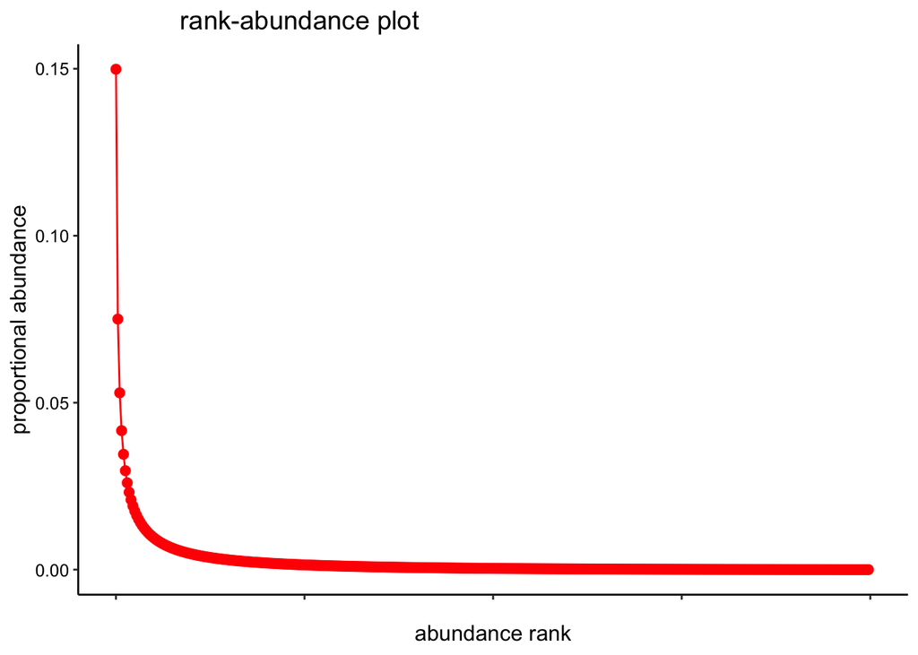

```r
rich <- 400


regional_abundances <-
  MeanRarity::fit_SAD(rich = rich, simpson = 25)$rel_abundances

# pdf("figures/SAD_400.pdf", height = 4, width = 4)
MeanRarity::radplot(regional_abundances) +
  # scale_y_log10() +
  ylab("proportional abundance")
```

```r
# dev.off()
```

Now, I’ll define some species as “rare” and others as common. Let’s define the top 100 species as common, and the bottom 100 as rare. This is one way to think about commonness and rarity… admittedly not the most typical way but it’s clear, right? The top quarter are common, the bottom quarter are rare, if you’re in the middle you’re neither common nore rare..

Let’s check it out.

```r
set.seed(666) # guarantees demonic outcomes
reps <- 9999 # set high so we're not caught off guard by noise
ss_a <- 200
ss_b <- 2 * ss_a
a <- rmultinom(reps, ss_a, prob = regional_abundances)
b <- rmultinom(reps, ss_b, prob = regional_abundances)
a_common<- a[1:100,]
a_rare <- a[301:400,]
b_common <- b[1:100,]
b_rare <- b[301:400,]
```

I expect to see double the number of individuals from rare species in “b” as “a”, and also double the number of individuals from common species. Is this what you expect?

```r
abundance_data <- map_dfr(c("a", "b"), function(samp){
  map_dfr(c("rare", "common"), function(rarity){
    data.frame(abundance = apply(get(paste(samp, rarity, sep = "_"))
               , 2, sum)
    , samp = samp
    , rarity = rarity
    )
  })
})

# look at means and se
pdf("figures/abundance_response.pdf", height = 3, width = 3)
abundance_data %>%
  ggplot(aes(samp, abundance, color = rarity)) +
  stat_summary(fun = mean
               , fun.max = function(x){mean(x) +  sd(x)/sqrt(length(x))}
               , fun.min = function(x){max(mean(x) - sd(x)/sqrt(length(x)), 0)}
               , size = 0.25) +
  theme_classic() +
  coord_trans(y = "log10") +
  scale_y_continuous(breaks = scales::breaks_log())
dev.off()
```

```r
ab_mod <- MASS::glm.nb(abundance ~ rarity*samp
              , data = abundance_data
              , control = glm.control(maxit = 999)
              )
ab_mod$theta # use poisson
```

```
## [1] 2.019535e+18
```

```r
ab_mod <- glm(abundance ~ rarity*samp
              , data = abundance_data
              , family = "poisson"
              )
```

If things went as I would expect, I’d see a significant effect of `samp` (approximate doubling) and a significant effect of `rarity` – and no interaction. Is that what I see?

```r
summary(ab_mod)
```

```
##
## Call:
## glm(formula = abundance ~ rarity * samp, family = "poisson",
##     data = abundance_data)
##
## Coefficients:
##                    Estimate Std. Error z value Pr(>|z|)
## (Intercept)       5.1898807  0.0007465 6951.91   <2e-16 ***
## rarityrare       -5.3403711  0.0108078 -494.12   <2e-16 ***
## sampb             0.6932305  0.0009143  758.20   <2e-16 ***
## rarityrare:sampb -0.0041021  0.0132456   -0.31    0.757
## ---
## Signif. codes:  0 '***' 0.001 '**' 0.01 '*' 0.05 '.' 0.1 ' ' 1
##
## (Dispersion parameter for poisson family taken to be 1)
##
##     Null deviance: 7809343  on 39995  degrees of freedom
## Residual deviance:   24874  on 39992  degrees of freedom
## AIC: 206255
##
## Number of Fisher Scoring iterations: 5
```

It is what I see! Note that the interaction term has tight CI around 0; this means we’re seeing basically the same change of about 2x in abundance of “rare” and “common” taxa. Unfortunately, my expectations might not carry over to the change in the number of *species* I see between `a` and `b`.

```r
ab_r_data <- map_dfr(c("a", "b"), function(samp){
  map_dfr(c("rare", "common"), function(rarity){
    data.frame(abundance = apply(get(paste(samp, rarity, sep = "_"))
                , 2, sum)
              , species = apply(get(paste(samp, rarity, sep = "_"))
                , 2, function(x){sum(x>0)})
    , samp = samp
    , rarity = rarity
    )
  })
})

pdf("figures/species_response.pdf", height = 3, width = 3)
ab_r_data %>%
  ggplot(aes(samp, species, color = rarity)) +
  stat_summary(fun = mean
               , fun.max = function(x){mean(x) +  sd(x)/sqrt(length(x))}
               , fun.min = function(x){max(mean(x) - sd(x)/sqrt(length(x)), 0)}
               , size = 0.25) +
  theme_classic() +
  coord_trans(y = "log10") +
  scale_y_continuous(breaks = scales::breaks_log())
dev.off()
```

Is this what a model says, too?

```r
# treating the count of species as... a count
# species_mod <- MASS::glm.nb(species ~ rarity*samp
#               , data = ab_r_data
#               , control = glm.control(maxit = 999)
#               )
#
#
# species_mod$theta # use poisson

species_mod <- glm(species ~ rarity*samp
              , data = ab_r_data
              , family = "poisson"
              )

summary(species_mod)
```

```
##
## Call:
## glm(formula = species ~ rarity * samp, family = "poisson", data = ab_r_data)
##
## Coefficients:
##                   Estimate Std. Error z value Pr(>|z|)
## (Intercept)       4.055057   0.001317 3079.78   <2e-16 ***
## rarityrare       -4.212898   0.010901 -386.45   <2e-16 ***
## sampb             0.276626   0.001746  158.44   <2e-16 ***
## rarityrare:sampb  0.407818   0.013387   30.46   <2e-16 ***
## ---
## Signif. codes:  0 '***' 0.001 '**' 0.01 '*' 0.05 '.' 0.1 ' ' 1
##
## (Dispersion parameter for poisson family taken to be 1)
##
##     Null deviance: 1691186  on 39995  degrees of freedom
## Residual deviance:   26775  on 39992  degrees of freedom
## AIC: 181204
##
## Number of Fisher Scoring iterations: 5
```

Yikes! Now the interaction is huge! I mean, it’s not wrong… You probably saw this coming… a large fraction of the common species were present in `a`, so that fraction (and thus the counts) just can’t increase that much in `b`. By contrast, only a percent or two of the rare species is typically found in `a`, so there is a lot of room to grow!

If we think about an increase in the *fraction* of the total species found in `a` vs. `b`, maybe we should be thinking of a logistic regression instead.

```r
ab_r_data <- ab_r_data %>%
  mutate(r_perc = species/100)
species_logistic <- glm(r_perc ~ samp * rarity # factors
                        , data = ab_r_data
                        , family = "binomial"
                        , weights = rep.int(100, length(abundance_data[,1])))
summary(species_logistic)
```

```
##
## Call:
## glm(formula = r_perc ~ samp * rarity, family = "binomial", data = ab_r_data,
##     weights = rep.int(100, length(abundance_data[, 1])))
##
## Coefficients:
##                   Estimate Std. Error z value Pr(>|z|)
## (Intercept)       0.309998   0.002024  153.15   <2e-16 ***
## sampb             0.846645   0.003097  273.37   <2e-16 ***
## rarityrare       -5.064432   0.011055 -458.11   <2e-16 ***
## sampb:rarityrare -0.153701   0.013704  -11.22   <2e-16 ***
## ---
## Signif. codes:  0 '***' 0.001 '**' 0.01 '*' 0.05 '.' 0.1 ' ' 1
##
## (Dispersion parameter for binomial family taken to be 1)
##
##     Null deviance: 2435062  on 39995  degrees of freedom
## Residual deviance:   36040  on 39992  degrees of freedom
## AIC: 167228
##
## Number of Fisher Scoring iterations: 5
```

Ok, In an earlier moment, this looked how I wanted, and now it doesn’t! I’m worried I kinda got lucky there… does the lack of interaction depend on the size of the sampling effect? On the sampling intensities in absolute terms?

```r
samp_eff <- seq(1.5, 5, 0.5)
base_ab <- c(100, 200, 400, 800, 1600)
reps <- 9999
eff_trend <- map_dfr(base_ab, function(ba){
  map_dfr(samp_eff, function(seff){
  a <- rmultinom(reps, ba, prob = regional_abundances)
  b <- rmultinom(reps, ba
                 *seff, prob = regional_abundances)
  a_common <- a[1:100,]
  a_rare <- a[301:400,]
  b_common <- b[1:100,]
  b_rare <- b[301:400,]
  dd <- map_dfr(c("a", "b"), function(samp){
  map_dfr(c("rare", "common"), function(rarity){
    data.frame(abundance = apply(get(paste(samp, rarity, sep = "_"))
                , 2, sum)
              , species = apply(get(paste(samp, rarity, sep = "_"))
                , 2, function(x){sum(x>0)})
              , samp = samp
              , rarity = rarity
              , base_abund = ba
              , sampling_effect = seff
    ) %>% mutate(rperc = species/100)
      })
    })
  })
})
eff_mods <- eff_trend %>%
  mutate(wt = 100) %>%
  nest_by(base_abund, sampling_effect) %>%
  mutate(my_mod = list(glm(rperc~samp*rarity
                        , data = data
                        , family = "binomial"
                        , weights = wt)))
effs <- eff_mods %>% summarize(intx = summary(my_mod)$coefficients[4,1]
            , pval = summary(my_mod)$coefficients[4,4])
pdf("figures/logistic_interaction_effect.pdf", width = 4, height = 4)
effs %>%
  ggplot(aes(sampling_effect
             , intx
             , size =  base_abund)) +
  geom_point(alpha = 0.5) +
  theme_classic() +
  labs(x = "sampling effect (b/a)"
       , y = "interaction term"
       , size = "abundance in 'a'") +
  scale_color_viridis_c() +
  scale_size_area()
dev.off()
```

- Interaction shrinks with the size of the sampling effect
- Interaction shrinks with sample sizes

# One thought: Why am I not using a beta-binomial?

```r
# not sure this is working, skip
# beta_mods <- eff_trend %>%
#   mutate(wt = 100) %>%
#   nest_by(base_abund, sampling_effect) %>%
#   mutate(my_mod = list(glmmTMB::glmmTMB(rperc~samp*rarity
#                         , data = data
#                         , family = glmmTMB::betabinomial
#                         , weights = wt)))
#
# betas <- beta_mods %>% summarize(intx = summary(my_mod)$coefficients$cond[4,1]
#             , pval = summary(my_mod)$coefficients$cond[4,4])
# betas %>%
#   ggplot(aes(sampling_effect
#              , pval
#              , color = boot::inv.logit(intx)
#              , size =  base_abund)) +
#   geom_point(alpha = 0.5) +
#   theme_classic() +
#   labs(x = "sampling effect (b/a)"
#        , y = "p value for sampling  x rarity coefficient"
#        , color = "interaction term effect size\n(response scale)"
#        , size = "abundance in 'a'") +
#   scale_color_viridis_c() +
#   scale_size_area()
```

# richness estimator makes things worse, which makes sense

The Chao1 richness estimator is among the best richness estimation tools that are amenable to data of this sort. In some sense, if it worked as advertised, it would remove the treatment effect, which it can nearly do for the common spp. It is very sensitive to the number of observed species, so it tends to jump up a lot from very low to kinda low sample sizes, as we expect with rare species between `a` and `b`. Which is exactly what we might want to control for.

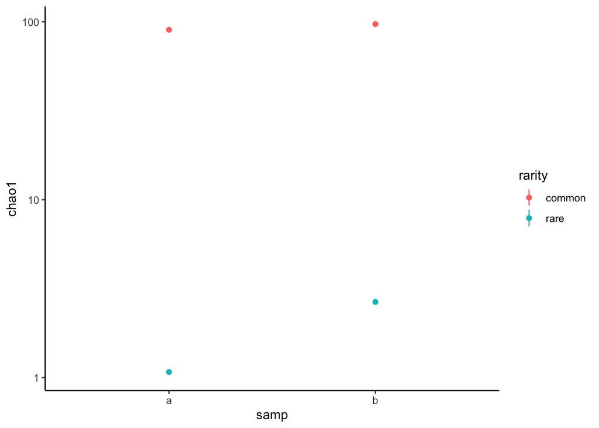

```r
ab_r_c1_data <- map_dfr(c("a", "b"), function(samp){
  map_dfr(c("rare", "common"), function(rarity){
    data.frame(abundance = apply(get(paste(samp, rarity, sep = "_"))
                , 2, sum)
              , species = apply(get(paste(samp, rarity, sep = "_"))
                , 2, function(x){sum(x>0)})
              , chao1 = apply(get(paste(samp, rarity, sep = "_"))
                , 2, function(x){ifelse(sum(x)>0, MeanRarity::Chao_Hill_abu(x, 1), 0)})
    , samp = samp
    , rarity = rarity
    )
  })
})

ab_r_c1_data %>%
  ggplot(aes(samp, chao1, color = rarity)) +
  stat_summary(fun = function(x){mean(x, na.rm = TRUE)}
               , fun.max = function(x){mean(x, na.rm = TRUE) +  sd(x, na.rm = TRUE)/sqrt(sum(!is.na(x)))}
               , fun.min = function(x){max(mean(x, na.rm = TRUE) - sd(x, na.rm = TRUE)/sqrt(sum(!is.na(x))), 0)}
               , size = 0.25) +
  theme_classic() +
  coord_trans(y = "log10") +
  scale_y_continuous(breaks = scales::breaks_log())
```

# Hazard models

Jonathan suggests this might be clearly framed as a Hazard model and so to use the complimentary log-log link in a GLM. Let’s sketch one out to make sure we have an idea of what is going on here. Let’s think about how smoking and asbestos exposure (we’ll treat them both as categorical) increase mortality.

```r
## same as ff.cloglog$linkfun:
cloglog <- function(x) log(-log(1-x))
## same as ff.cloglog$linkinv
gompertz <- function(x) 1-exp(-exp(x))
```

```r
baseline_mortality <- 0.05 # 5% background mortality
# 10% (double) chance of dying if you smoke
# ditto asbestos exposure
# but effect of asbestos is 1.5x as big for smokers than for non-smokers

ss <- 9999# individuals we're looking at
individual <- 1:ss
smoking  <- sample(0:1, ss, prob = c(3,1), replace = TRUE)
asbestos <-  sample(0:1, ss, prob = c(9,1), replace = TRUE)
dead <- sapply(individual, function(x){sample(0:1
                                              , 1
                                              , prob = c(
  1- (1*smoking[x] + 1* asbestos[x] + 3 * asbestos[x] * smoking[x] + 1
      ) * baseline_mortality
  , (1*smoking[x] + 1* asbestos[x] + 3 * asbestos[x] * smoking[x] + 1
     ) * baseline_mortality))
  })


clog_dat <- data.frame(individual, smoking, asbestos, dead)

clog_mod <- glm(dead~smoking*asbestos, family = binomial(link = "cloglog"), data = clog_dat)
summary(clog_mod)
```

```
##
## Call:
## glm(formula = dead ~ smoking * asbestos, family = binomial(link = "cloglog"),
##     data = clog_dat)
##
## Coefficients:
##                  Estimate Std. Error z value Pr(>|z|)
## (Intercept)      -3.01901    0.05582 -54.085  < 2e-16 ***
## smoking           0.75191    0.08697   8.645  < 2e-16 ***
## asbestos          0.87864    0.12440   7.063 1.63e-12 ***
## smoking:asbestos  0.42034    0.18093   2.323   0.0202 *
## ---
## Signif. codes:  0 '***' 0.001 '**' 0.01 '*' 0.05 '.' 0.1 ' ' 1
##
## (Dispersion parameter for binomial family taken to be 1)
##
##     Null deviance: 5103.6  on 9998  degrees of freedom
## Residual deviance: 4871.4  on 9995  degrees of freedom
## AIC: 4879.4
##
## Number of Fisher Scoring iterations: 6
```

```r
exp(clog_mod$coefficients)
```

```
##      (Intercept)          smoking         asbestos smoking:asbestos
##       0.04884957       2.12104740       2.40763237       1.52247654
```

```r
# c log log thinks:
#
# there's a multiplicative rln between the two factors (forgetting the interaction term itself)
# What does the interaction mean? A deviation from the strict power law rln between the two hazards
# now, the question is what is the rln between the hazards? Constant ratio...
# This is a constant difference in the model?
# so it doesn't mean: drop the interaction,  should have no hazard associated with rarity
# Should the log hazards be additive??
# Problem: non-linear averaging associated with the fact that the species within group don't have same abundance
# but it might be ok for now.



species_cloglog <- glm(r_perc ~ samp * rarity # factors
                        , data = ab_r_data
                        , family = binomial(link = cloglog)
                        , weights = rep.int(100, length(abundance_data[,1])))


summary(species_cloglog)
```

```
##
## Call:
## glm(formula = r_perc ~ samp * rarity, family = binomial(link = cloglog),
##     data = ab_r_data, weights = rep.int(100, length(abundance_data[,
##         1])))
##
## Coefficients:
##                   Estimate Std. Error z value Pr(>|z|)
## (Intercept)      -0.150694   0.001358 -111.00   <2e-16 ***
## sampb             0.508459   0.001843  275.84   <2e-16 ***
## rarityrare       -4.608032   0.010907 -422.50   <2e-16 ***
## sampb:rarityrare  0.180225   0.013401   13.45   <2e-16 ***
## ---
## Signif. codes:  0 '***' 0.001 '**' 0.01 '*' 0.05 '.' 0.1 ' ' 1
##
## (Dispersion parameter for binomial family taken to be 1)
##
##     Null deviance: 2435062  on 39995  degrees of freedom
## Residual deviance:   36040  on 39992  degrees of freedom
## AIC: 167228
##
## Number of Fisher Scoring iterations: 5
```

```r
#family = binomial(link = cloglog))
```

# next step: simplify

JD intuits non-linear averaging might be the problem here. Make species so they have the same mean abundances.

```r
rare <- 1
common <- 10
ab_a <- rmultinom(reps, 200, c(rep(rare, 100), rep(common, 100)))
ab_b <- rmultinom(reps, 400, c(rep(rare, 100), rep(common, 100)))
a_common <- ab_a[101:200,]
a_rare <- ab_a[1:100,]
b_common <- ab_b[101:200,]
b_rare <- ab_b[1:100,]
dd <- map_dfr(c("a", "b"), function(samp){
  map_dfr(c("rare", "common"), function(rarity){
    data.frame(abundance = apply(get(paste(samp, rarity, sep = "_"))
                , 2, sum)
              , species = apply(get(paste(samp, rarity, sep = "_"))
                , 2, function(x){sum(x>0)})
              , samp = samp
              , rarity = rarity
    ) %>% mutate(rperc = species/100)
      })
})

# still a problem for logistic
species_logistic_simple <- glm(rperc ~ samp * rarity
                        , data = dd
                        , family = "binomial"
                        , weights = rep.int(100, length(dd[,1])))


summary(species_logistic_simple)
```

```
##
## Call:
## glm(formula = rperc ~ samp * rarity, family = "binomial", data = dd,
##     weights = rep.int(100, length(dd[, 1])))
##
## Coefficients:
##                   Estimate Std. Error z value Pr(>|z|)
## (Intercept)       1.652146   0.002722   606.9   <2e-16 ***
## sampb             1.978754   0.006869   288.1   <2e-16 ***
## rarityrare       -3.265933   0.003825  -853.8   <2e-16 ***
## sampb:rarityrare -1.185704   0.007689  -154.2   <2e-16 ***
## ---
## Signif. codes:  0 '***' 0.001 '**' 0.01 '*' 0.05 '.' 0.1 ' ' 1
##
## (Dispersion parameter for binomial family taken to be 1)
##
##     Null deviance: 2246897  on 39995  degrees of freedom
## Residual deviance:   35491  on 39992  degrees of freedom
## AIC: 199069
##
## Number of Fisher Scoring iterations: 4
```

```r
# but interaction gone with cloglog
species_cloglog_simple <- glm(rperc ~ samp * rarity
                        , data = dd
                        , family = binomial(link = cloglog)
                        , weights = rep.int(100, length(dd[,1])))



summary(species_cloglog_simple)
```

```
##
## Call:
## glm(formula = rperc ~ samp * rarity, family = binomial(link = cloglog),
##     data = dd, weights = rep.int(100, length(dd[, 1])))
##
## Coefficients:
##                   Estimate Std. Error  z value Pr(>|z|)
## (Intercept)       0.602935   0.001250  482.327   <2e-16 ***
## sampb             0.693721   0.002094  331.272   <2e-16 ***
## rarityrare       -2.308894   0.002757 -837.436   <2e-16 ***
## sampb:rarityrare  0.003607   0.003706    0.973     0.33
## ---
## Signif. codes:  0 '***' 0.001 '**' 0.01 '*' 0.05 '.' 0.1 ' ' 1
##
## (Dispersion parameter for binomial family taken to be 1)
##
##     Null deviance: 2246897  on 39995  degrees of freedom
## Residual deviance:   35491  on 39992  degrees of freedom
## AIC: 199069
##
## Number of Fisher Scoring iterations: 4
```

```r
exp(coef(species_cloglog_simple))
```

```
##      (Intercept)            sampb       rarityrare sampb:rarityrare
##       1.82747526       2.00114788       0.09937106       1.00361376
```

# consider an offset

JD suggested an offset for total number of individuals observed in the group. The idea is that hazards are basically increasingly linearly with the ?cloglog of sample size, which is what led us to the original model. If I can find the version of this that works, including the offset will pull from the intercept term (it should basically make the rare and common groups identical, in effect) but will not alter the main effect of treatment. Because there is no longer a difference in intercepts between the rarity groups, we’re hoping there also won’t be any kind of interaction.

Revisiting this like 6 months later, I have a guess about a potential form for the offsets and I’m going to mess with it here.

```r
# need to add some data, I guess
dd <- dd %>% mutate(start_ab = rep(abundance[1:19998], 2)
                    , end_ab = rep(abundance[19999:nrow(dd)], 2))

# this won't work becuase cloglog(bunch of integers) is no good!
# clog_off <- glm(rperc ~ samp * rarity + offset(cloglog(start_ab))
#                         , data = dd
#                         , family = binomial(link = cloglog)
#                         , weights = rep.int(100, length(dd[,1])))

# try just log(count) for the offset (use log x+1?)
clog_off <- glm(rperc ~ samp * rarity + offset(log(dd$start_ab))
                        , data = dd
                        , family = binomial(link = cloglog)
                        , weights = rep.int(100, length(dd[,1])))

summary(clog_off)
```

```
##
## Call:
## glm(formula = rperc ~ samp * rarity + offset(log(dd$start_ab)),
##     family = binomial(link = cloglog), data = dd, weights = rep.int(100,
##         length(dd[, 1])))
##
## Coefficients:
##                    Estimate Std. Error   z value Pr(>|z|)
## (Intercept)      -4.5996780  0.0012503 -3678.896   <2e-16 ***
## sampb             0.6936612  0.0020945   331.181   <2e-16 ***
## rarityrare       -0.0016087  0.0027576    -0.583    0.560
## sampb:rarityrare -0.0001909  0.0037101    -0.051    0.959
## ---
## Signif. codes:  0 '***' 0.001 '**' 0.01 '*' 0.05 '.' 0.1 ' ' 1
##
## (Dispersion parameter for binomial family taken to be 1)
##
##     Null deviance: 220690  on 39995  degrees of freedom
## Residual deviance:  42545  on 39992  degrees of freedom
## AIC: 206123
##
## Number of Fisher Scoring iterations: 4
```

```r
# is it symmetrical?
clog_off_bw <- glm(rperc ~ samp * rarity + offset(log(dd$end_ab))
                        , data = dd
                        , family = binomial(link = cloglog)
                        , weights = rep.int(100, length(dd[,1])))

summary(clog_off_bw)
```

```
##
## Call:
## glm(formula = rperc ~ samp * rarity + offset(log(dd$end_ab)),
##     family = binomial(link = cloglog), data = dd, weights = rep.int(100,
##         length(dd[, 1])))
##
## Coefficients:
##                   Estimate Std. Error   z value Pr(>|z|)
## (Intercept)      -5.292983   0.001250 -4233.847  < 2e-16 ***
## sampb             0.694115   0.002095   331.383  < 2e-16 ***
## rarityrare       -0.008157   0.002760    -2.956  0.00312 **
## sampb:rarityrare  0.007808   0.003708     2.106  0.03524 *
## ---
## Signif. codes:  0 '***' 0.001 '**' 0.01 '*' 0.05 '.' 0.1 ' ' 1
##
## (Dispersion parameter for binomial family taken to be 1)
##
##     Null deviance: 211509  on 39995  degrees of freedom
## Residual deviance:  32075  on 39992  degrees of freedom
## AIC: 195653
##
## Number of Fisher Scoring iterations: 4
```

```r
ddd <- dd
ddd[which(dd$samp == "a"), "samp"] <- "d"
clog_off_bw <- glm(rperc ~ samp * rarity + offset(log(dd$end_ab))
                        , data = ddd
                        , family = binomial(link = cloglog)
                        , weights = rep.int(100, length(dd[,1])))

summary(clog_off_bw)
```

```
##
## Call:
## glm(formula = rperc ~ samp * rarity + offset(log(dd$end_ab)),
##     family = binomial(link = cloglog), data = ddd, weights = rep.int(100,
##         length(dd[, 1])))
##
## Coefficients:
##                    Estimate Std. Error   z value Pr(>|z|)
## (Intercept)      -4.5988684  0.0016806 -2736.430   <2e-16 ***
## sampd            -0.6941146  0.0020946  -331.383   <2e-16 ***
## rarityrare       -0.0003493  0.0024771    -0.141   0.8879
## sampd:rarityrare -0.0078080  0.0037083    -2.106   0.0352 *
## ---
## Signif. codes:  0 '***' 0.001 '**' 0.01 '*' 0.05 '.' 0.1 ' ' 1
##
## (Dispersion parameter for binomial family taken to be 1)
##
##     Null deviance: 211509  on 39995  degrees of freedom
## Residual deviance:  32075  on 39992  degrees of freedom
## AIC: 195653
##
## Number of Fisher Scoring iterations: 4
```

```r
clog_off2 <- glm(rperc ~ samp * rarity + offset(log(dd$abundance + 1))
                        , data = dd
                        , family = binomial(link = cloglog)
                        , weights = rep.int(100, length(dd[,1])))

summary(clog_off2) # don't want that, it kills the treatment effect by including it in the offset
```

```
##
## Call:
## glm(formula = rperc ~ samp * rarity + offset(log(dd$abundance +
##     1)), family = binomial(link = cloglog), data = dd, weights = rep.int(100,
##     length(dd[, 1])))
##
## Coefficients:
##                   Estimate Std. Error   z value Pr(>|z|)
## (Intercept)      -4.605166   0.001250 -3683.292  < 2e-16 ***
## sampb             0.003549   0.002095     1.694   0.0902 .
## rarityrare       -0.049935   0.002757   -18.109  < 2e-16 ***
## sampb:rarityrare  0.025118   0.003707     6.777 1.23e-11 ***
## ---
## Signif. codes:  0 '***' 0.001 '**' 0.01 '*' 0.05 '.' 0.1 ' ' 1
##
## (Dispersion parameter for binomial family taken to be 1)
##
##     Null deviance: 19637  on 39995  degrees of freedom
## Residual deviance: 19203  on 39992  degrees of freedom
## AIC: 182781
##
## Number of Fisher Scoring iterations: 4
```

```r
# nope!

# try including log(count) as a term and seeing what kind of coefficient(s) it gets
clog_term <- glm(rperc ~ samp * rarity + log(start_ab)
                        , data = dd
                        , family = binomial(link = cloglog)
                        , weights = rep.int(100, length(dd[,1])))


summary(clog_term)
```

```
##
## Call:
## glm(formula = rperc ~ samp * rarity + log(start_ab), family = binomial(link = cloglog),
##     data = dd, weights = rep.int(100, length(dd[, 1])))
##
## Coefficients:
##                   Estimate Std. Error z value Pr(>|z|)
## (Intercept)      -1.202660   0.033594 -35.800   <2e-16 ***
## sampb             0.693628   0.002094 331.220   <2e-16 ***
## rarityrare       -1.502540   0.015171 -99.041   <2e-16 ***
## log(start_ab)     0.347060   0.006452  53.788   <2e-16 ***
## sampb:rarityrare  0.002245   0.003706   0.606    0.545
## ---
## Signif. codes:  0 '***' 0.001 '**' 0.01 '*' 0.05 '.' 0.1 ' ' 1
##
## (Dispersion parameter for binomial family taken to be 1)
##
##     Null deviance: 2246897  on 39995  degrees of freedom
## Residual deviance:   32567  on 39991  degrees of freedom
## AIC: 196147
##
## Number of Fisher Scoring iterations: 4
```

```r
# Hmmm. if we take the total count of individuals as a given... incl. its impact on treatment
# clog_off <- glm(rperc ~ samp * rarity + offset(log(abundance))
#                         , data = dd
#                         , family = binomial(link = cloglog)
#                         , weights = rep.int(100, length(dd[,1])))


# clog_off <- glm(rperc ~ samp * rarity + log(start_ab)
#                         , data = dd
#                         , family = binomial(link = cloglog)
#                         , weights = rep.int(100, length(dd[,1])))
dd <- dd %>% mutate(start_rich = rep(species[1:19998],2))
clog_off <- glm(rperc ~ samp * rarity + offset(log(start_rich))
                        , data = dd
                        , family = binomial(link = cloglog)
                        , weights = rep.int(100, length(dd[,1])))

clog_off <- glm(rperc ~ samp * rarity + log(start_rich/100)
                        , data = dd
                        , family = binomial(link = cloglog)
                        , weights = rep.int(100, length(dd[,1])))


clog_off <- glm(rperc ~ samp * rarity + offset(log(1/abundance))
                        , data = dd
                        , family = binomial(link = cloglog)
                        , weights = rep.int(100, length(dd[,1])))
# consider using the link function and rel abund for offsets
# this seems like a good guess.
dd <- dd %>% mutate(relab = start_ab/sum(start_ab))
clog_off <- glm(rperc ~ samp * rarity + offset(log(-log(1-relab)))
                        , data = dd
                        , family = binomial(link = cloglog)
                        , weights = rep.int(100, length(dd[,1])))

summary(clog_off)
```

```
##
## Call:
## glm(formula = rperc ~ samp * rarity + offset(log(-log(1 - relab))),
##     family = binomial(link = cloglog), data = dd, weights = rep.int(100,
##         length(dd[, 1])))
##
## Coefficients:
##                    Estimate Std. Error  z value Pr(>|z|)
## (Intercept)      10.6020042  0.0012503 8479.652   <2e-16 ***
## sampb             0.6936612  0.0020945  331.181   <2e-16 ***
## rarityrare       -0.0015884  0.0027576   -0.576    0.565
## sampb:rarityrare -0.0001909  0.0037101   -0.051    0.959
## ---
## Signif. codes:  0 '***' 0.001 '**' 0.01 '*' 0.05 '.' 0.1 ' ' 1
##
## (Dispersion parameter for binomial family taken to be 1)
##
##     Null deviance: 220692  on 39995  degrees of freedom
## Residual deviance:  42545  on 39992  degrees of freedom
## AIC: 206123
##
## Number of Fisher Scoring iterations: 4
```